# Practical Machine Learning Course Project

Steven Aurousseau

December 27, 2015

## Background

Using devices such as Jawbone Up, Nike FuelBand, and Fitbit it is now possible to collect a large amount of data about personal activity relatively inexpensively. These type of devices are part of the quantified self movement – a group of enthusiasts who take measurements about themselves regularly to improve their health, to find patterns in their behavior, or because they are tech geeks. One thing that people regularly do is quantify how much of a particular activity they do, but they rarely quantify how well they do it.

In this project, the goal was to use data collected from accelerometers on the belt, forearm, arm, and dumbell of 6 participants. They were asked to perform barbell lifts correctly and incorrectly, a total of 5 different ways:

1. exactly according to the specification (**Class A**),
2. throwing the elbows to the front (**Class B**),
3. lifting the dumbbell only halfway (**Class C**),
4. lowering the dumbbell only halfway (**Class D**)
5. throwing the hips to the front (**Class E**)

Read more at http://groupware.les.inf.puc-rio.br/har#ixzz3vXJtUIv8 *Ugulino, W.; Cardador, D.; Vega, K.; Velloso, E.; Milidiu, R.; Fuks, H. Wearable Computing: Accelerometers’ Data Classification of Body Postures and Movements*

## Load Data

```r
library(caret, quietly = TRUE); library(ggplot2, quietly = TRUE)
setwd("~/Box Sync/Programming/Coursera - Data Science/8.0 Practical Machine Learning/course project")

# load Weight Lifting Exercise (WLE) dataset
if (! "trainingWLE.csv" %in% dir(getwd())) {
        trainURL <- "https://d396qusza40orc.cloudfront.net/predmachlearn/pml-training.csv"
        download.file(trainURL, destfile = "trainingWLE.csv")
        rm(trainURL)
}
if (! "testingWLE.csv" %in% dir(getwd())) {
        testURL <- "https://d396qusza40orc.cloudfront.net/predmachlearn/pml-testing.csv"
        download.file(testURL, destfile = "testingWLE.csv")
        rm(testURL)
}
training <- read.csv("trainingWLE.csv")   # 20 160
testing <- read.csv("testingWLE.csv")  # 19622 160
```

## Cleaning Data

### Count NA’s in each column and clean-up

```r
unique(colSums(!is.na(training))) # NA's are whole column or 406 rows
```

```
## [1] 19622   406
```

```r
nas = sapply(training, function(x) {sum(is.na(x))})
training <- training[, names(training) %in% names(nas[nas < 407])] # 19622 93
testing <- testing[, names(testing) %in% names(nas[nas < 407])] # 20 92
rm(nas)
```

### Remove near zero variance and descriptor variables

```r
# remove description and time cols
training <- training[,-c(1:7)]
testing <- testing[, -c(1:7)]
# remove near zero variance (NZV) variables
nzv <- nearZeroVar(training, saveMetrics=TRUE)
training <- training[, names(training) %in% rownames((nzv[nzv$nzv == 0, ]))]
testing <- testing[, names(testing) %in% rownames((nzv[nzv$nzv == 0, ]))]
rm(nzv)
```

### Split training data into train/validate with 60/40 split

```r
set.seed(89)
inTrain <- createDataPartition(y=training$classe, p = 0.60, list=FALSE)
training <- training[inTrain, ]
validate <- training[-inTrain, ]
rm(inTrain)
```

## Classification Tree

Apply classification tree to dataset:

```r
mod.ct1 <- train(classe ~., method = 'rpart', data = training)
```

```r
mod.ct1
```

```
## CART
##
## 11776 samples
##    52 predictor
##     5 classes: 'A', 'B', 'C', 'D', 'E'
##
## No pre-processing
## Resampling: Bootstrapped (25 reps)
## Summary of sample sizes: 11776, 11776, 11776, 11776, 11776, 11776, ...
## Resampling results across tuning parameters:
##
##   cp          Accuracy   Kappa       Accuracy SD  Kappa SD
##   0.03357855  0.5088255  0.36163368  0.05130981   0.08319050
##   0.05924695  0.3927351  0.17106166  0.05528056   0.09280945
##   0.11260085  0.3372546  0.08080323  0.03625338   0.05665091
##
## Accuracy was used to select the optimal model using  the largest value.
## The final value used for the model was cp = 0.03357855.
```

```r
mod.ct1$finalModel
```

```
## n= 11776
##
## node), split, n, loss, yval, (yprob)
##       * denotes terminal node
##
##  1) root 11776 8428 A (0.28 0.19 0.17 0.16 0.18)
##    2) roll_belt< 130.5 10807 7469 A (0.31 0.21 0.19 0.18 0.11)
##      4) pitch_forearm< -34 917    7 A (0.99 0.0076 0 0 0) *
##      5) pitch_forearm>=-34 9890 7462 A (0.25 0.23 0.21 0.2 0.12)
##       10) magnet_dumbbell_y< 437.5 8357 5982 A (0.28 0.18 0.24 0.19 0.11)
##         20) roll_forearm< 122.5 5137 3027 A (0.41 0.18 0.18 0.16 0.059) *
##         21) roll_forearm>=122.5 3220 2161 C (0.082 0.18 0.33 0.23 0.18) *
##       11) magnet_dumbbell_y>=437.5 1533  776 B (0.035 0.49 0.04 0.22 0.21) *
##    3) roll_belt>=130.5 969   10 E (0.01 0 0 0 0.99) *
```

## Tree Dendogram

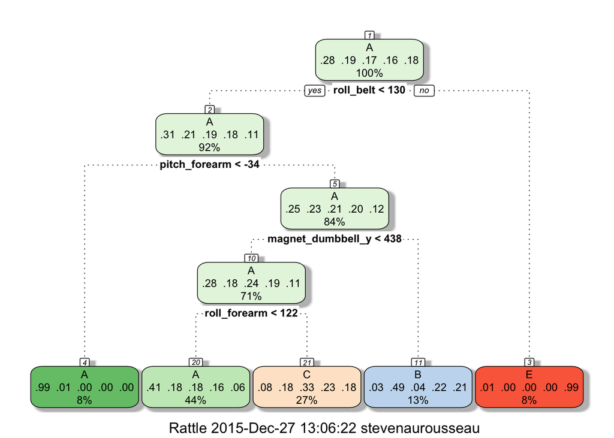

```r
# plot dendogram with rattle package
library(rattle, quietly = TRUE)
fancyRpartPlot(mod.ct1$finalModel)
```

Overall the classification tree model predicts 0.51 accuracy for the training dataset, which is only marginally above guessing. Also, the classe D exercise is dropped completely from the final model.

## Random Forest with Caret Package

### Training the model

A Random Forest training model was applied to the data with the caret package. Out of bag (OOB) error estimate method was used for the bootstrap datasets.

```r
set.seed(89)
mod.rf5 <- train(classe ~., data = training,
                 method = 'rf',
                 trControl=trainControl(method='oob', seeds = c(89)),
                 proximity = TRUE)
mod.rf5
```

```
## Random Forest
##
## 11776 samples
##    52 predictor
##     5 classes: 'A', 'B', 'C', 'D', 'E'
##
## No pre-processing
## Resampling results across tuning parameters:
##
##   mtry  Accuracy   Kappa
##    2    0.9909986  0.9886134
##   27    0.9913383  0.9890435
##   52    0.9859885  0.9822751
##
## Accuracy was used to select the optimal model using  the largest value.
## The final value used for the model was mtry = 27.
```

The accuracy of the final training model is 0.991 with mtry = 27. Giving an error rate of: (1 - 0.991)*100 = 0.9%.

## Plot Model Convergence

[figure not shown]

```r
plot(mod.rf5)
```